# 4-1 선형 모델

## 2. 로지스틱 회귀 모델(Logistic Regression Model)

### 이진 분류

- 링크 함수: 선형 회귀 모델의 출력의 스케일을 바꾸어주는 함수입니다.

> 선형회귀 모델의 출력은 $[-\infty, \infty]$이고 대상 변수의 영역은 [0, 1] 입니다.

> 만일 선형 회귀 모델을 분류 문제에 그대로 사용하게 한다면 출력이 음(Negative)의 클래스는 0을 중심으로 양(Positive)의 클래스는 1을 중심으로 출력이 모이도록 분포해야 합니다. $[-\infty, \infty]$를 범위로 하고 있어 구조상 최적의 해를 찾기 쉽지 않습니다.

> 선형회귀 모델이 음으로 갈수록 음(Negative)의 클래스 양수로 갈 수록 양(Positive) 클래스일 정도를 나타내게 하게 하도록 스케일을 변경시켜준다면, 최적의 해를 보다 찾기 쉬워지고 출력을 직관적으로 이해하기 쉽게 해줍니다.
- 로짓(Logit) 함수: 확률의 영역 $[0, 1]$의 수를 $[-\infty, \infty]$ 으로 바꾸어 주는 함수 입니다.

> $odd(\hat{y}) = \frac{\hat{y}}{1-\hat{y}}$ : $[0, 1]$의 수를 $[0, \infty]$로 바꾸어 줍니다.

> $logit(\hat{y}) = log(\frac{\hat{y}}{1-\hat{y}})$: $[0, 1]$의 수를 $[-\infty, \infty]$로 바꾸어 줍니다.
- 로지스틱(Logistic) 함수: $[-\infty, \infty]$의 수를 $[0, 1]$의 수로 바꾸어 줍니다. Logit의 역함수입니다.

> $x = log(\frac{\hat{y}}{1-\hat{y}})$

> $e^x = \frac{\hat{y}}{1-\hat{y}}$

> $(1-\hat{y})e^x = \hat{y}$

> $(1 + e^x)\hat{y} = e^x$

> $\hat{y} = \frac{e^x}{1+e^x} = \frac{1}{1+e^{-x}}$
- 선형회귀 모델에서 링크 함수로 로지스틱(Logistic) 함수를 사용하는 선형 회귀 모델을 **로지스틱 회귀 모델**이라 합니다.
- 이진 크로스 엔트로피(Binary Cross Entropy): 이진 분류의 손실 함수입니다.

> $L_{Logistic}(y, \hat{y}) = -\left(ylog(\hat{y}) + (1 - y)log(1 - \hat{y})\right)$

### 다중 클래스 분류

- Softmax 함수: 다중 클래스 분류의 문제에서 클래스 수만큼의 로짓(Logit)에서 확률로 변환해주는 함수입니다.

> $softmax(p) = \frac{e^{p_i}}{\sum_{i=1}^ce^{p_i}}$, $c$: 클래스의 수
- 크로스 엔트로피(Cross Entropy): 다중 분류의 손실 함수입니다.

> $L_{Logistic}(y, \hat{y}) = -\sum_{i=1}^cy_ilog(\hat{y_i})$,

> $y_i$: 대상 변수 y가 i 클래스 여부를 나타내는 벡터, $\hat{y_i}$: i 클래스일 확률 예측을 나타내는 벡터

**[Ex.5]**

df_train가 df_test에서 성별(Sex)이 ‘F’, ‘M’ 인 경우만 뽑아 df_train2, df_test2셋을 만들어,

성별(Sex)을 맞추는 로지스틱 회귀 모델을 만들어 df_train2로 학습을 시키고,

df_test2로 성능을 측정합니다.

성능 측정은 AUC(Area under of receiver characteristic Curve)로 합니다.

```r
# 데이터 필터링
df_train2 <- df_train %>% filter(Sex %in% c('F', 'M'))
df_test2 <- df_test %>% filter(Sex %in% c('F', 'M'))

# 열 선택
X_cols <- setdiff(names(df_train2), 'Sex')
X_cols
```

```
[1] "Length"   "Diameter" "Height"   "Whole"    "Shucked"  "Viscera"  "Shell"    "Rings"
```

```r
library(pROC)
# 데이터 전처리: 표준화
preProcessParams <- preProcess(df_train2[, X_cols], method = c('center', 'scale'))
df_train2_std <- predict(preProcessParams, df_train2[, X_cols])
df_test2_std <- predict(preProcessParams, df_test2[, X_cols])

# 로지스틱 회귀 모델 학습
model <- glmnet(as.matrix(df_train2_std), df_train2$Sex, family = "binomial")

# 예측 확률
train_prob <- predict(model, newx = as.matrix(df_train2_std), type = "response")[, 1]
test_prob <- predict(model, newx = as.matrix(df_test2_std), type = "response")[, 1]

# ROC AUC 점수 계산
train_roc_auc <- roc(df_train2$Sex, train_prob)
test_roc_auc <- roc(df_test2$Sex, test_prob)
auc(train_roc_auc)
```

```
Area under the curve: 0.5
```

```r
auc(test_roc_auc)
```

```
Area under the curve: 0.5
```

#### one-vs-rest(OVR)과 multinomial 비교

- OVR에서는 각 평면들이 교차하는 영역에서의 부정확한 경계가 만들어질 수 있고, 이러한 문제는 클래스의 분포가 불균형할 때 심하게 나타납니다.
- 반면, OVR은 multinomial에 비해 직관적이며 해석이 용이합니다.

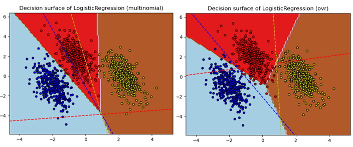

※ 이미지 출처: https://scikit-learn.org/stable/auto_examples/linear_model/plot_logistic_multinomial.html

## 선형 모델의 장단점

### 장점

- 계산 효율성
- 해석이 용이
- 이해하기 쉬운 개념

### 단점

- 대상 변수와 입력 변수간의 선형성을 지녀야 성능을 발휘

> 성능 향상을 위한 많은 속성 엔지니어링이 필요합니다.
- 이상치에 민감